# Model Selection for Linear Regression Model

Group 21: Haowen Chen, Xin Hu, Zhichao Yang

## Project Introduction

Model selection is the process of selecting a model from a set of candidate models. Many statistical techniques involve model selection either implicitly or explicitly: e.g., hypothesis tests require selecting between a null hypothesis and alternative hypothesis model; an autoregressive model requires selecting the order p; in this tutorial, a regression model requires selecting specific predictors.

A good model selection technique will balance goodness of fit with simplicity, which means under a certain performance requirement set by researchers, the best model should be as simple as possible. If a model includes too many predictors, the most common issue would be overfitting, in which case the model gives good predictions to training data but performs much worse when it comes to data not used in fitting the model. Overfitting model normally gives low bias but high variance. Conversely, when there are too few predictors in a model, the issue of underfitting may show up, and gives poor predictions to data used or not used for model fitting. Underfitting models normally have low variance but high bias.

Testing based and criterion-based approaches are the two main approaches for model (variable) selection. Testing-based approaches include backward elimination, forward selection, stepwise regression, etc. In this category, variables are selected based on whether they are significant or not when they are added/removed. For criterion-based approaches, we have some idea about the purpose for which a model is intended, so we might propose some measures of how well a given model meets that purpose. Then a model that optimizes a criterion which balances goodness-of-fit will be chosen. Some examples of criterion-based approaches include AIC/BIC, adjusted R2, Mallow’s cp, etc.

More introduction and details about model selection can be found in *Statistics: An Introduction for Climate Scientists* By DelSole and Tippett **Chapter 11**

## Method Introduction

#### Stepwise Regression

The idea of stepwise regression is to build a regression model by adding/removing predictors step-by-step, until the pre-set significance level is met for all predictors. Each step in the stepwise regression procedure can be identified as “forward selection” or “backward selection”, which mean adding a predictor or removing a existing predictor respectively.

**Forward selection** starts with a null model, and adds variables to the model one-by-one. The criteria of which variable to include each time is as following: 1) test each variable that is not already in the model, 2) check the significance of all of them to see if their P-value is below certain level, and 3) choose the one that is the most significant. The drawbacks of the forward selection is: every time we add one variable into the model, we ignore the fact that the new variable may render some of the existing variables to be non-significant. Unlike forward selection, the procedure of **backward selection** method is: 1) start with a model of all variables, 2) check the significance of each variable, and 3) drop one with the least significance each time until all the variables remained are statistically significant.

#### AIC & BIC

As two important examples of criterion-based model selection approach, AIC and BIC have two similar objective functions to minimize as shown below.
$$AIC=n\ln(\frac{RSS}{n})+2(p+1)$$
$$BIC=n\ln(\frac{RSS}{n})+(p+1)\ln n$$
where n is the number of training data and p is the number of parameters in the model.

AIC is founded on information theory: it offers an estimate of the relative information lost when a given model is used to represent the process that generated the data. In doing so, it deals with the trade-off between the goodness of fit of the model and the complexity of the model. BIC on the other hand, puts a larger penalty on the complexity of the model as training data gets larger. As a result, AIC is generally considered better when prediction is the aim, despite there still is some debate over the topic.

It is worth noting that neither AIC nor BIC provides a test of a model in the sense of testing a null hypothesis. It tells nothing about the absolute quality of a model, only the quality relative to other models. Thus, if all the candidate models fit poorly, they will not give any warning of that.

## Data Manipulation

Our data is [Home Sale Prices from King County](https://www.kaggle.com/harlfoxem/housesalesprediction). The introduction and documentation of the data can be found in the prior link. For the purpose of showing the model selection methods properly. We choose a subset of the predictors and observations.

```r
# Load the library
library(tidyverse)

# Import the data
lmdata<-read_csv('kc_house_data.csv')

# Get a subset of the predictors(p=13)
lmdata<-select(lmdata,-c(id,date,zipcode,sqft_basement,lat,long,sqft_living15,sqft_lot15))

# Get a subset of the observations(n=200) randomly
set.seed(100)
lmdata<-lmdata[sample(nrow(lmdata),200),]

# Show the head of the data
head(lmdata)
```

```
## # A tibble: 6 x 13
##    price bedrooms bathrooms sqft_living sqft_lot floors waterfront  view
##    <dbl>    <int>     <dbl>       <int>    <int>  <dbl>      <int> <int>
## 1 176000        2      1.00         770     5200      1          0     0
## 2 370000        2      1.00         850     6213      1          0     0
## 3 875909        4      2.50        3610    13292      2          0     0
## 4 100000        2      1.00         770    17334      1          0     0
## 5 580000        3      1.75        1850     2797      1          0     0
## 6 577000        5      2.75        1940     5000      2          0     0
## # ... with 5 more variables: condition <int>, grade <int>,
## #   sqft_above <int>, yr_built <int>, yr_renovated <int>
```

## Implementation

### R

First and foremost, we should build a linear model with all the available predictors included, so that we can have an understanding of the model, as well as to use the result of this model in the upcoming model selections. **price~.** inside the lm function means the linear model includes all the columns in the data as predictors other than **price**.

```r
lm_result1<-lm(price~.,data=lmdata)
summary(lm_result1)
```

```
##
## Call:
## lm(formula = price ~ ., data = lmdata)
##
## Residuals:
##     Min      1Q  Median      3Q     Max
## -648573 -107534  -22206  101899 1465406
##
## Coefficients:
##                Estimate Std. Error t value Pr(>|t|)
## (Intercept)   3.314e+06  1.697e+06   1.954 0.052239 .
## bedrooms     -3.655e+04  2.499e+04  -1.463 0.145274
## bathrooms     2.091e+04  4.585e+04   0.456 0.648881
## sqft_living   1.987e+02  5.935e+01   3.348 0.000985 ***
## sqft_lot      6.143e-01  3.566e-01   1.722 0.086637 .
## floors        5.236e+04  4.253e+04   1.231 0.219814
## waterfront    5.919e+05  1.965e+05   3.013 0.002948 **
## view          1.094e+05  2.606e+04   4.198 4.16e-05 ***
## condition     3.178e+04  3.088e+04   1.029 0.304676
## grade         1.801e+05  2.707e+04   6.652 3.10e-10 ***
## sqft_above   -1.149e+02  5.412e+01  -2.124 0.035003 *
## yr_built     -2.280e+03  8.685e+02  -2.626 0.009367 **
## yr_renovated  1.119e+02  5.249e+01   2.131 0.034378 *
## ---
## Signif. codes:  0 '***' 0.001 '**' 0.01 '*' 0.05 '.' 0.1 ' ' 1
##
## Residual standard error: 233200 on 187 degrees of freedom
## Multiple R-squared:  0.7281, Adjusted R-squared:  0.7106
## F-statistic: 41.73 on 12 and 187 DF,  p-value: < 2.2e-16
```

#### Stepwise regression

For stepwise regression, the function *step* should be called and the *direction* is set to *both* so that the algorithm can add and drop predictors in every iteration. Once it is called, the iterating process will proceed by itself.

From the summary of the first iteration where we include all possible predictors, we can see that the model dropped *bathrooms*, which is the predictor with the highest P-value in this model. As a result, in the second iteration when we analyze the impact of each predictor, the variable *bathrooms* has a plus sign instead of a minus sign in front of it, meaning the impact is measured when the variable *bathrooms* is added to our model.

Finally, when dropping/adding any variable will not give a positive impact to our model in terms of performance, the stepwise process is done.

```r
lm_result2<-step(lm_result1, direction = "both")
```

```
## Start:  AIC=4956.35
## price ~ bedrooms + bathrooms + sqft_living + sqft_lot + floors +
##     waterfront + view + condition + grade + sqft_above + yr_built +
##     yr_renovated
##
##                Df  Sum of Sq        RSS    AIC
## - bathrooms     1 1.1307e+10 1.0177e+13 4954.6
## - condition     1 5.7594e+10 1.0224e+13 4955.5
## - floors        1 8.2401e+10 1.0248e+13 4956.0
## <none>                       1.0166e+13 4956.4
## - bedrooms      1 1.1628e+11 1.0282e+13 4956.6
## - sqft_lot      1 1.6129e+11 1.0327e+13 4957.5
## - sqft_above    1 2.4520e+11 1.0411e+13 4959.1
## - yr_renovated  1 2.4692e+11 1.0413e+13 4959.2
## - yr_built      1 3.7476e+11 1.0541e+13 4961.6
## - waterfront    1 4.9341e+11 1.0659e+13 4963.8
## - sqft_living   1 6.0927e+11 1.0775e+13 4966.0
## - view          1 9.5793e+11 1.1124e+13 4972.4
## - grade         1 2.4056e+12 1.2572e+13 4996.8
##
## Step:  AIC=4954.57
## price ~ bedrooms + sqft_living + sqft_lot + floors + waterfront +
##     view + condition + grade + sqft_above + yr_built + yr_renovated
##
##                Df  Sum of Sq        RSS    AIC
## - condition     1 6.1696e+10 1.0239e+13 4953.8
## <none>                       1.0177e+13 4954.6
## - floors        1 1.0616e+11 1.0283e+13 4954.6
## - bedrooms      1 1.0659e+11 1.0284e+13 4954.7
## - sqft_lot      1 1.6070e+11 1.0338e+13 4955.7
## + bathrooms     1 1.1307e+10 1.0166e+13 4956.4
## - sqft_above    1 2.6894e+11 1.0446e+13 4957.8
## - yr_renovated  1 2.7164e+11 1.0449e+13 4957.8
## - yr_built      1 3.7749e+11 1.0555e+13 4959.9
## - waterfront    1 5.2357e+11 1.0701e+13 4962.6
## - sqft_living   1 8.6293e+11 1.1040e+13 4968.9
## - view          1 9.6019e+11 1.1138e+13 4970.6
## - grade         1 2.4627e+12 1.2640e+13 4995.9
##
## Step:  AIC=4953.78
```

[output cut: 40 more lines]

```
##
##                Df  Sum of Sq        RSS    AIC
## <none>                       1.0404e+13 4953.0
## - sqft_lot      1 1.2203e+11 1.0526e+13 4953.3
## + floors        1 8.3526e+10 1.0320e+13 4953.4
## + bedrooms      1 6.2765e+10 1.0341e+13 4953.8
## + condition     1 3.6150e+10 1.0368e+13 4954.3
## - sqft_above    1 1.8826e+11 1.0592e+13 4954.6
## + bathrooms     1 1.9052e+10 1.0385e+13 4954.6
## - yr_renovated  1 2.0830e+11 1.0612e+13 4954.9
## - yr_built      1 5.2994e+11 1.0934e+13 4960.9
## - waterfront    1 5.8177e+11 1.0986e+13 4961.9
## - sqft_living   1 7.2398e+11 1.1128e+13 4964.4
## - view          1 9.9859e+11 1.1403e+13 4969.3
## - grade         1 2.7933e+12 1.3197e+13 4998.5
```

#### Akaike information criterion (AIC)

For AIC and BIC, we use *step* function again and specify the penalty for the number of freedom. For instance, we have $k=2$ in AIC and $k=log(n)$ in BIC, implying that BIC normally gives a larger penalty on the number of parameters in the model according to the definition of BIC. Once the model selection is done, we should expect a smaller number of predictors in BIC than AIC below.

```r
lm_result3<-step(lm_result1, k=2)
```

```
## Start:  AIC=4956.35
## price ~ bedrooms + bathrooms + sqft_living + sqft_lot + floors +
##     waterfront + view + condition + grade + sqft_above + yr_built +
##     yr_renovated
##
##                Df  Sum of Sq        RSS    AIC
## - bathrooms     1 1.1307e+10 1.0177e+13 4954.6
## - condition     1 5.7594e+10 1.0224e+13 4955.5
## - floors        1 8.2401e+10 1.0248e+13 4956.0
## <none>                       1.0166e+13 4956.4
## - bedrooms      1 1.1628e+11 1.0282e+13 4956.6
## - sqft_lot      1 1.6129e+11 1.0327e+13 4957.5
## - sqft_above    1 2.4520e+11 1.0411e+13 4959.1
## - yr_renovated  1 2.4692e+11 1.0413e+13 4959.2
## - yr_built      1 3.7476e+11 1.0541e+13 4961.6
## - waterfront    1 4.9341e+11 1.0659e+13 4963.8
## - sqft_living   1 6.0927e+11 1.0775e+13 4966.0
## - view          1 9.5793e+11 1.1124e+13 4972.4
## - grade         1 2.4056e+12 1.2572e+13 4996.8
##
## Step:  AIC=4954.57
## price ~ bedrooms + sqft_living + sqft_lot + floors + waterfront +
##     view + condition + grade + sqft_above + yr_built + yr_renovated
##
##                Df  Sum of Sq        RSS    AIC
## - condition     1 6.1696e+10 1.0239e+13 4953.8
## <none>                       1.0177e+13 4954.6
## - floors        1 1.0616e+11 1.0283e+13 4954.6
## - bedrooms      1 1.0659e+11 1.0284e+13 4954.7
## - sqft_lot      1 1.6070e+11 1.0338e+13 4955.7
## - sqft_above    1 2.6894e+11 1.0446e+13 4957.8
## - yr_renovated  1 2.7164e+11 1.0449e+13 4957.8
## - yr_built      1 3.7749e+11 1.0555e+13 4959.9
## - waterfront    1 5.2357e+11 1.0701e+13 4962.6
## - sqft_living   1 8.6293e+11 1.1040e+13 4968.9
## - view          1 9.6019e+11 1.1138e+13 4970.6
## - grade         1 2.4627e+12 1.2640e+13 4995.9
##
## Step:  AIC=4953.78
## price ~ bedrooms + sqft_living + sqft_lot + floors + waterfront +
```

[output cut: 30 more lines]

```
##
## Step:  AIC=4952.98
## price ~ sqft_living + sqft_lot + waterfront + view + grade +
##     sqft_above + yr_built + yr_renovated
##
##                Df  Sum of Sq        RSS    AIC
## <none>                       1.0404e+13 4953.0
## - sqft_lot      1 1.2203e+11 1.0526e+13 4953.3
## - sqft_above    1 1.8826e+11 1.0592e+13 4954.6
## - yr_renovated  1 2.0830e+11 1.0612e+13 4954.9
## - yr_built      1 5.2994e+11 1.0934e+13 4960.9
## - waterfront    1 5.8177e+11 1.0986e+13 4961.9
## - sqft_living   1 7.2398e+11 1.1128e+13 4964.4
## - view          1 9.9859e+11 1.1403e+13 4969.3
## - grade         1 2.7933e+12 1.3197e+13 4998.5
```

#### Bayes information criterion (BIC)

```r
lm_result4<-step(lm_result1, k=log(nrow(lmdata)))
```

```
## Start:  AIC=4999.23
## price ~ bedrooms + bathrooms + sqft_living + sqft_lot + floors +
##     waterfront + view + condition + grade + sqft_above + yr_built +
##     yr_renovated
##
##                Df  Sum of Sq        RSS    AIC
## - bathrooms     1 1.1307e+10 1.0177e+13 4994.2
## - condition     1 5.7594e+10 1.0224e+13 4995.1
## - floors        1 8.2401e+10 1.0248e+13 4995.5
## - bedrooms      1 1.1628e+11 1.0282e+13 4996.2
## - sqft_lot      1 1.6129e+11 1.0327e+13 4997.1
## - sqft_above    1 2.4520e+11 1.0411e+13 4998.7
## - yr_renovated  1 2.4692e+11 1.0413e+13 4998.7
## <none>                       1.0166e+13 4999.2
## - yr_built      1 3.7476e+11 1.0541e+13 5001.2
## - waterfront    1 4.9341e+11 1.0659e+13 5003.4
## - sqft_living   1 6.0927e+11 1.0775e+13 5005.6
## - view          1 9.5793e+11 1.1124e+13 5011.9
## - grade         1 2.4056e+12 1.2572e+13 5036.4
##
## Step:  AIC=4994.15
## price ~ bedrooms + sqft_living + sqft_lot + floors + waterfront +
##     view + condition + grade + sqft_above + yr_built + yr_renovated
##
##                Df  Sum of Sq        RSS    AIC
## - condition     1 6.1696e+10 1.0239e+13 4990.1
## - floors        1 1.0616e+11 1.0283e+13 4990.9
## - bedrooms      1 1.0659e+11 1.0284e+13 4990.9
## - sqft_lot      1 1.6070e+11 1.0338e+13 4992.0
## - sqft_above    1 2.6894e+11 1.0446e+13 4994.1
## - yr_renovated  1 2.7164e+11 1.0449e+13 4994.1
## <none>                       1.0177e+13 4994.2
## - yr_built      1 3.7749e+11 1.0555e+13 4996.1
## - waterfront    1 5.2357e+11 1.0701e+13 4998.9
## - sqft_living   1 8.6293e+11 1.1040e+13 5005.1
## - view          1 9.6019e+11 1.1138e+13 5006.9
## - grade         1 2.4627e+12 1.2640e+13 5032.2
##
## Step:  AIC=4990.06
## price ~ bedrooms + sqft_living + sqft_lot + floors + waterfront +
```

[output cut: 68 more lines]

```
## - yr_built      1 7.2588e+11 1.1389e+13 4984.9
## - sqft_living   1 7.7333e+11 1.1436e+13 4985.7
## - view          1 1.3804e+12 1.2043e+13 4996.0
## - grade         1 2.6865e+12 1.3349e+13 5016.6
##
## Step:  AIC=4975.1
## price ~ sqft_living + waterfront + view + grade + yr_built
##
##               Df  Sum of Sq        RSS    AIC
## <none>                      1.0846e+13 4975.1
## - waterfront   1 4.8667e+11 1.1333e+13 4978.6
## - sqft_living  1 7.6051e+11 1.1607e+13 4983.4
## - yr_built     1 9.3472e+11 1.1781e+13 4986.3
## - view         1 1.2958e+12 1.2142e+13 4992.4
## - grade        1 2.7877e+12 1.3634e+13 5015.5
```

As predicted before, AIC gives an optimal model with 8 predictors while BIC only has 5. Note that this time we start with the full model and only consider dropping predictors until dropping any one would increase model’s AIC value.

### Stata

#### Stepwise Regression

In stata, stepwise selection method is achieved by **stepwise** command. **pe(#)** is for forward selection and **pr(#)** is for backward selection, where # is the number of significance level wanted. The following **regress** command is used to specify the regression model where “price” is placed at first as the dependent variable before the 12 variables ready to be added.

```
. stepwise, pr(.2) pe(.15): regress price bedrooms bathrooms sqft_living sqft_l
> ot floors waterfront view condition grade sqft_above yr_built yr_renovated
```

The result is as following:

```
. stepwise, pr(.2) pe(.15): regress price bedrooms bathrooms sqft_living sqft_l
> ot floors waterfront view condition grade sqft_above yr_built yr_renovated
                      begin with full model
p = 0.6489 >= 0.2000  removing bathrooms
p = 0.2871 >= 0.2000  removing condition
p = 0.2217 >= 0.2000  removing bedrooms
p = 0.2165 >= 0.2000  removing floors

      Source |       SS           df       MS      Number of obs   =       200
-------------+----------------------------------   F(8, 191)       =     61.92
       Model |  2.6984e+13         8  3.3730e+12   Prob > F        =    0.0000
    Residual |  1.0404e+13       191  5.4471e+10   R-squared       =    0.7217
-------------+----------------------------------   Adj R-squared   =    0.7101
       Total |  3.7388e+13       199  1.8788e+11   Root MSE        =    2.3e+05

------------------------------------------------------------------------------
       price |      Coef.   Std. Err.      t    P>|t|     [95% Conf. Interval]
-------------+----------------------------------------------------------------
  sqft_above |  -92.09825   49.54009    -1.86   0.065    -189.8142    5.617694
yr_renovated |   97.98611   50.10715     1.96   0.052    -.8483454    196.8206
 sqft_living |   169.9357    46.6129     3.65   0.000     77.99353    261.8779
    sqft_lot |   .5255762   .3511394     1.50   0.136     -.167033    1.218185
       grade |   188573.9   26333.23     7.16   0.000     136632.7    240515.2
  waterfront |   632038.3   193397.7     3.27   0.001     250568.6     1013508
        view |   110982.1   25920.41     4.28   0.000     59855.11    162109.2
    yr_built |  -2116.374   678.5175    -3.12   0.002    -3454.724   -778.0237
       _cons |    3055019    1271305     2.40   0.017     547417.9     5562620
------------------------------------------------------------------------------
```

#### AIC and BIC

```
. regress price bedrooms bathrooms sqft_living sqft_lot floors waterfront view
> condition grade sqft_above yr_built yr_renovated

      Source |       SS           df       MS      Number of obs   =       200
-------------+----------------------------------   F(12, 187)      =     41.73
       Model |  2.7222e+13        12  2.2685e+12   Prob > F        =    0.0000
    Residual |  1.0166e+13       187  5.4364e+10   R-squared       =    0.7281
-------------+----------------------------------   Adj R-squared   =    0.7106
       Total |  3.7388e+13       199  1.8788e+11   Root MSE        =    2.3e+05

------------------------------------------------------------------------------
       price |      Coef.   Std. Err.      t    P>|t|     [95% Conf. Interval]
-------------+----------------------------------------------------------------
    bedrooms |  -36553.76    24993.5    -1.46   0.145    -85859.22    12751.69
   bathrooms |   20907.86   45845.26     0.46   0.649    -69532.51    111348.2
 sqft_living |   198.7002   59.35365     3.35   0.001     81.61147     315.789
    sqft_lot |   .6143092   .3566439     1.72   0.087    -.0892533    1.317872
      floors |   52361.89   42530.95     1.23   0.220    -31540.23      136264
  waterfront |   591865.1   196460.3     3.01   0.003     204301.7    979428.5
        view |   109398.2   26061.41     4.20   0.000      57986.1    160810.4
   condition |   31784.07   30879.78     1.03   0.305    -29133.44    92701.58
       grade |   180078.9   27071.28     6.65   0.000     126674.6    233483.3
  sqft_above |  -114.9439   54.12243    -2.12   0.035    -221.7129   -8.174887
    yr_built |  -2280.251   868.4847    -2.63   0.009    -3993.538   -566.9644
yr_renovated |   111.8681   52.49038     2.13   0.034     8.318696    215.4175
       _cons |    3314377    1696541     1.95   0.052    -32442.59     6661197
------------------------------------------------------------------------------

. estat ic

Akaike's information criterion and Bayesian information criterion

-----------------------------------------------------------------------------
       Model |        Obs  ll(null)  ll(model)      df         AIC        BIC
-------------+---------------------------------------------------------------
           . |        200 -2879.193  -2748.963      13    5523.927   5566.805
-----------------------------------------------------------------------------
               Note: N=Obs used in calculating BIC; see [R] BIC note.
```

[output not shown]

[output not shown]

[output not shown]

[output not shown]

[output not shown]

[output not shown]

[output not shown]

[output not shown]

[output not shown]

[output not shown]

### SAS

The **reg** procedure is one of many regression procedures in the SAS System. It is a general-purpose procedure for regression, while other SAS regression procedures provide more specialized applications. For simple regression, we just need **model** statement in **reg** procedure. First we build a linear model using all predictors.

```
proc reg data = lmdata;
   model price = bedrooms bathrooms sqft_living sqft_lot floors waterfront
                 view condition grade sqft_above yr_built yr_renovated;
run;
```

Then **SAS** will return very detailed results(not shown in the tutorial) of the linear model which includes analysis variance, fit statistics, parameter estimates, fit diagnostics(plots) and residual plots.

#### Stepwise Regression

Option **selection** in the **model** statement is for specifiing model selection methods. The first argument of the **selection** must be one of the following: *adjrsq*, *b*, *backward*, *cp*, *maxr*, *minr*, *none*, *requare*, *stepwise*. Besides, all the predictors have an assumed entry and exit significance level $\alpha$ in the stepwise regression. An entry significance level $\alpha$ = 0.15, specified in the **slentry=0.15** option, means a variable must have a $p-value \le 0.15$ to enter the model during stepwise regression. An exit significance level of 0.15, specified in the **slstay=0.15** option, means a variable must have a $p-value \ge 0.15$ to leave the model during stepwise regression.

```
/* Use stepwise to select variables */

proc reg data = lmdata outest=lmdata_result1;
   model price = bedrooms bathrooms sqft_living sqft_lot floors waterfront
                 view condition grade sqft_above yr_built yr_renovated / slstay=0.15 slentry=0.15 selection = stepwise;
run;
```

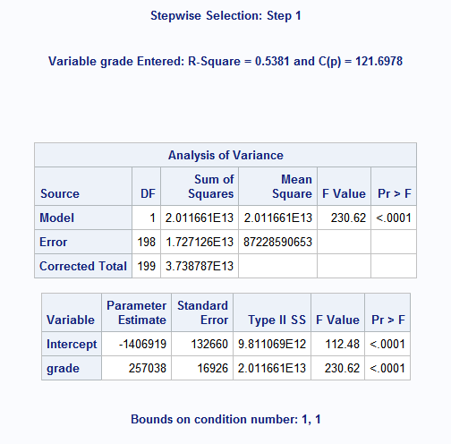

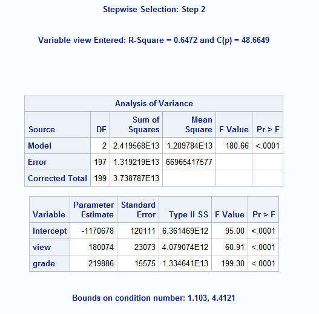

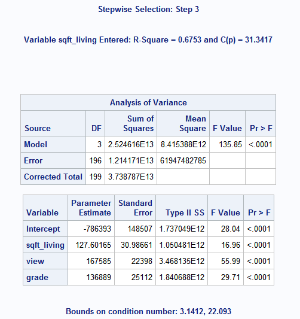

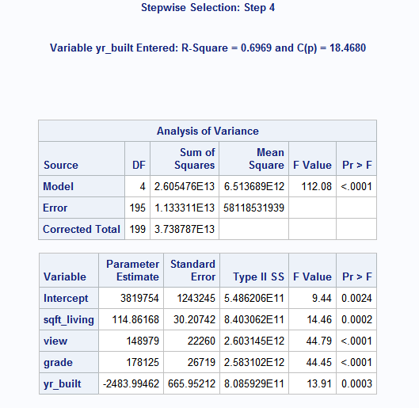

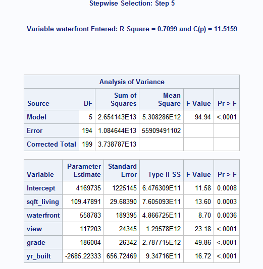

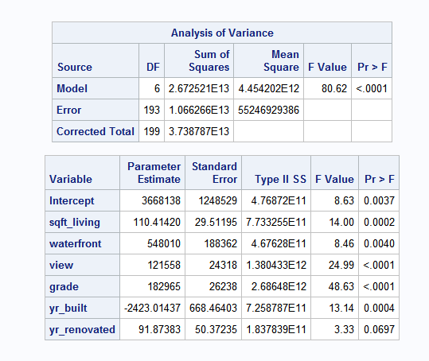

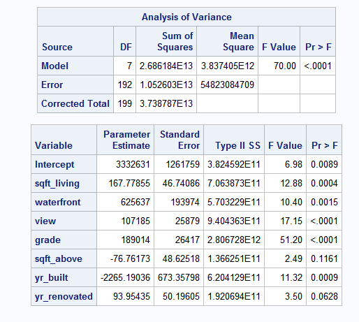

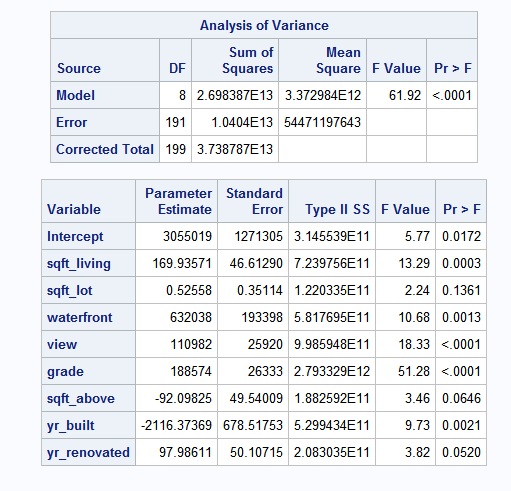

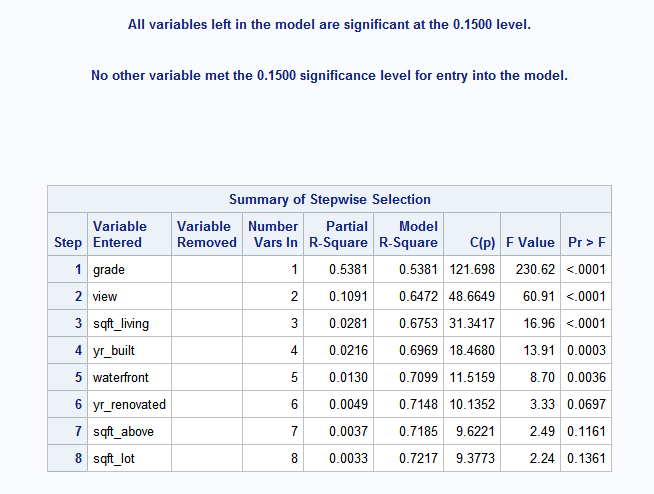

#### AIC and BIC

Now change the arguments of the **selection** to *rsquare aic bic* and then we can get the model selected by AIC and BIC.

```
/* Use AIC BIC to select variables */

proc reg data = lmdata outest=lmdata_result2;
   model price = bedrooms bathrooms sqft_living sqft_lot floors waterfront
                 view condition grade sqft_above yr_built yr_renovated / selection = rsquare aic bic;

/* Sort the data by value of AIC */
proc sort data=lmdata_result2;
   by _aic_;

/* Drop useless columns */
data lmdata_AIC;
   set lmdata_result2;
   drop Obs _MODEL_ _TYPE_ _DEPVAR_ _RMSE_ price _IN_ _P_ _EDF_ _RSQ_ _BIC_;

/* We can get the best n model by setting obs=n */
proc print data=lmdata_AIC(obs=4);
run;
```

The result is shown as follows and the model we get by AIC is
$$price\sim sqft\_living+sqft\_lot+waterfront+view+grade+sqft\_above+yr\_built+yr\_renovated$$

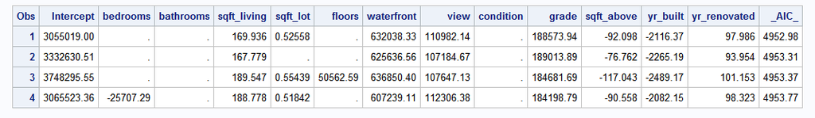

```
/* Sort the data by value of BIC */
proc sort data=lmdata_result2;
   by _bic_;

/* Drop useless columns */
data lmdata_BIC;
   set lmdata_result2;
   drop Obs _MODEL_ _TYPE_ _DEPVAR_ _RMSE_ price _IN_ _P_ _EDF_ _RSQ_ _AIC_;

/* We can get the best n model by setting obs=n */
proc print data=lmdata_BIC(obs=4);
run;
```

The result is shown as follows and the model we get by BIC is
$$price\sim sqft\_living+sqft\_lot+waterfront+view+grade+sqft\_above+yr\_built+yr\_renovated$$

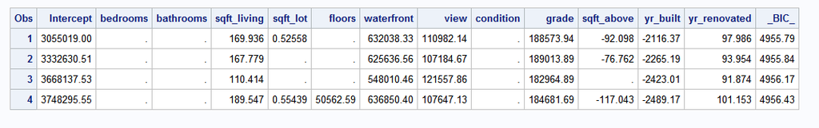

PS: The result is the same as the result we get by AIC, which is different from what we get in **R**. The reason is that SAS looks like calculate the BIC for every possible subset of variables for models so that it can get a better result.